# Predicting Temperature with Air Quality Dataset

Sever Fundatureanu

August 13, 2017

# Introduction

- Application Goal: Allow the user to explore the relationship between Temperature and one of Ozone, Solar Radiation or Wind
- Features
  - Plot display of Temperature vs one of the 3 inputs mentioned above
  - Prediction of Temperature for any value chosen by the user for the chosen input
- Data: **airquality** dataset in R
- App URL: [Predict Temperature using Air Quality Dataset](https://sever-dataproducts.shinyapps.io/Assignment4/)

# Application Inputs

- Radio-buttons with choice of one of Ozone, Solar Radiation, Wind
- Slider for choosing the input value for prediction of temperature

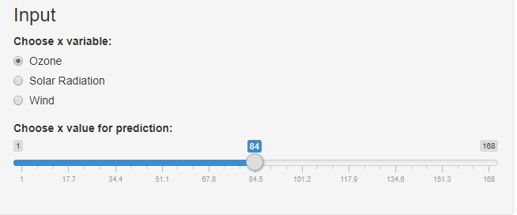

# Application Output

- Temperature value predicted using the linear model between Temperature and chosen input
- Plot of temperature vs. chosen input (below snapshot uses Ozone as input)
  - In blue we mark the linear model
  - In red we mark the predicted point and coordinates based on the user’s input value

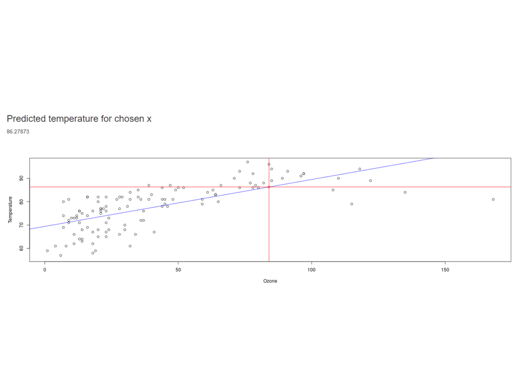

# Implementation

- Based on **Shiny**
- The UI uses a *pageWithSidebar* layout
- The server uses *reactive* functions to
  - recompute the linear model whenever the uses chooses a different input
  - recompute the prediction of temperature whenever the user chooses a new value fom the slider
  - update the slider range in the UI when the user chooses a new type of input
- Implementation code can be found [here](https://github.com/fundatureanu-sever/DataProducts/tree/gh-pages/Assignment4)

# Summary

We used R’s **airquality** dataset to build a **Shiny** app which allows the user to

- display the relationship between Temperature and one of Ozone, Solar Radiation or Wind
- flexibly predict Temperature based on any input value